# WCARO output 1 use case 1

Akvo - data science

11/9/2021

# 1 Introduction

Access to an improved water source is the first step towards achieving safe water coverage for a population. When different methodologies are used to report coverage, wide discrepancies appear in the reported figures for people with access to safe water and those left unserved. However, planners and policy makers require correct and updated information to estimate real needs and to assess the scale of vulnerabilities across unserved / underserved populations, as well as to make projections for future allocations. In this overview, we demonstrate how such differences appear by using three different ways of estimating water access in the region of Kambia.

Country governments are required to report their progress of WASH services on all the three key indicators of SDG6 and grade their level of services in the JMP ladder. While it is relatively easier to measure water coverage by recording the number of water points that are installed, reporting on ‘basic’ water services according to the JMP requires also recording whether a round trip to the water point takes less than 30 minutes. For higher levels of the JMP ladder where water safety and reliability need to be reported upon, the parameters are stricter and require more detailed information.

*See Annex 1 and the footnote for more information about the data sources used.*

# 2 Methodology

Many countries continue to face challenges in recording and updating their water coverage data, either due to lack of resources or the capacity to collect information about the SDG parameters. Also, during reporting, measurements of water coverage seldom take into account aspects of functionality of water points or the density of population in locations of the communities they serve. Using Akvo’s example of data from Kambia (mapped in 2016) , we propose to highlight the extent of differences that can appear in coverage and access figures, when parameters of functionality and population densities are also included into the calculations. These differences have far reaching ramifications on plans and policies that address safe water coverage across communities.

## 2.1 Methodology for estimating water supply coverage using Sphere guidelines

### 2.1.1 Example 1: Measuring access by disaggregating type and functionality of water sources (calculations based on *sphere guidelines*[^1])

In the first example we wish to demonstrate how the coverage and access data is influenced by the type and functionality of the water points. We use data from a water point mapping in 2016 that was conducted in the district of Kambia, in Sierra Leone and district level population projections from the ministry[^2]. The mapping survey used the following parameters to classify the water points:

- Improved water points (tap, handpump, open hand well, mechanised hand well)
- Unimproved water points (unprotected well, pond, river etc.)
- Total water points (total Improved and unimproved)
- Functional (functioning and in use) / not functional water points (defunct, damaged, under repair etc.)

The *Sphere Guidelines* provide a method to determine the number of people a specific type of water point can potentially serve i.e. projected coverage. Using the mapped data of Kambia, we have calculated the potential coverage as per these guidelines. The calculations show that if we were to merely consider the total 750 water points mapped in Kambia in 2016, they can be expected to serve approximately 0.29 million people as per the guideline definitions. (Refer Table 1)

Table 1: Water points & estimated population coverage

| District | Total no. of water points | Possible coverage (nr of people) |
| --- | --- | --- |
| Kambia | 750 | 291950 |

<sup>a</sup> National Water Point Mapping 2016  
<sup>b</sup> Sphere guidelines

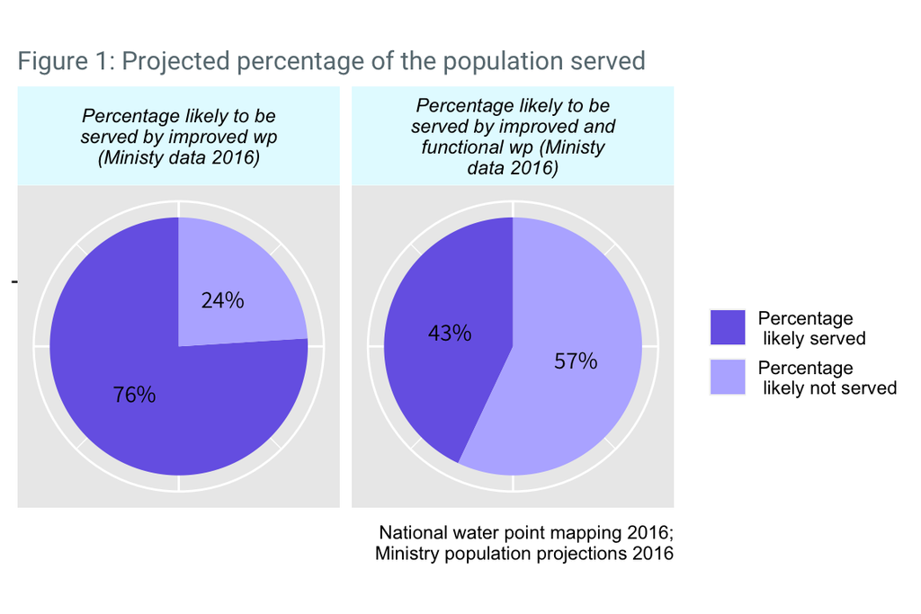

Table 2: Coverage of water points by category

| District | Improved/ unimproved water point | Number of water points | Potential coverage (nr of people) |
| --- | --- | --- | --- |
| Kambia | improved | 686 | 272450 |
| Kambia | unimproved | 64 | 19500 |

<sup>a</sup> National Water Point Mapping 2016  
<sup>b</sup> Sphere guidelines

Table 3: Functionality by type of water point

| District | Functional / not functional | Number of water points | Possible coverage (nr of people) |
| --- | --- | --- | --- |
| Kambia | Functional and in use | 336 | 127750 |
| Kambia | Not functional | 414 | 164200 |

<sup>a</sup> National Water Point Mapping 2016  
<sup>b</sup> Sphere guidelines

In Table 4 we further provide details of the status of functionality of the mapped water points in Kambia. Only 336 of the 750 water points i.e. 45%, were reported to be functional and in use. From the rest, 300 water points i.e. 40% , were reported to be broken down and the remaining were in various stages of non functionality and non use. This information provides sufficient evidence to highlight the need to look at types of functionality, to decide coverage / access of water points and brings to light the fact that having a water point does not necessarily ensure having access to water supply.

Table 4 : Functionality of water points

| District | Functional / not functional | Number of water points | Possible coverage (nr of people) |
| --- | --- | --- | --- |
| Kambia | Functional and in use | 306 | 117750 |
| Kambia | Not functional | 380 | 154700 |
| Kambia | Functional and in use | 30 | 10000 |
| Kambia | Not functional | 34 | 9500 |

<sup>a</sup> National Water Point Mapping 2016  
<sup>b</sup> Sphere guidelines

Table 5: Population coverage of water points

| District | Improved / unimproved | Functional / not functional | Percentage of the population likely to be served (%) |
| --- | --- | --- | --- |
| Kambia | improved | Functional and in use | 33 |
| Kambia | improved | Not functional | 44 |
| Kambia | unimproved | Functional and in use | 3 |
| Kambia | unimproved | Not functional | 3 |

<sup>a</sup> National Water Point Mapping 2016  
<sup>b</sup> Sphere guidelines

### 2.1.2 Example 2: Measuring access vis a vis population density

Kambia is about 3000 square kilometers and is estimated to have about 800 villages. In order to decide whether communities are accessing water within 30 minutes for a round trip for collection (as required by the JMP to categorize as ‘basic’ services), it is also important to know whether the water points are dispersed in a manner that that match the way communities are also dispersed, i.e. the population density. **In this example, we demonstrate a method to estimate access to water services in relation to the population densities in Kambia.**

In Example 2, we first look at the population density of the location and then compare it with the distribution of water points in the same locations, to estimate the concentration of people i.e. the number of people likely to be dependent on each water point.

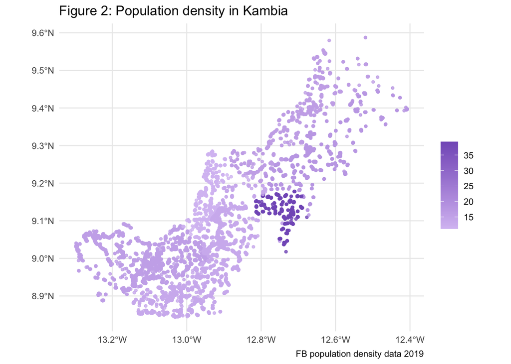

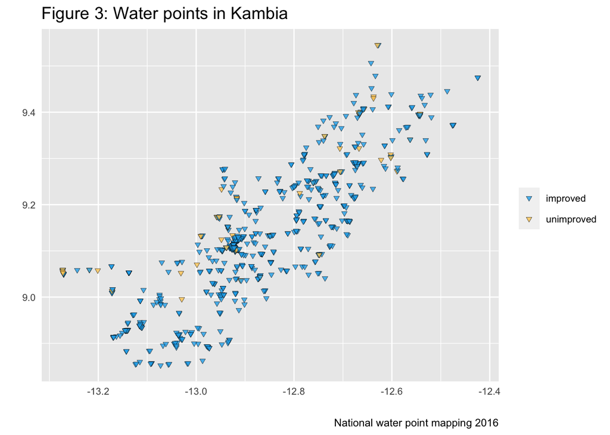

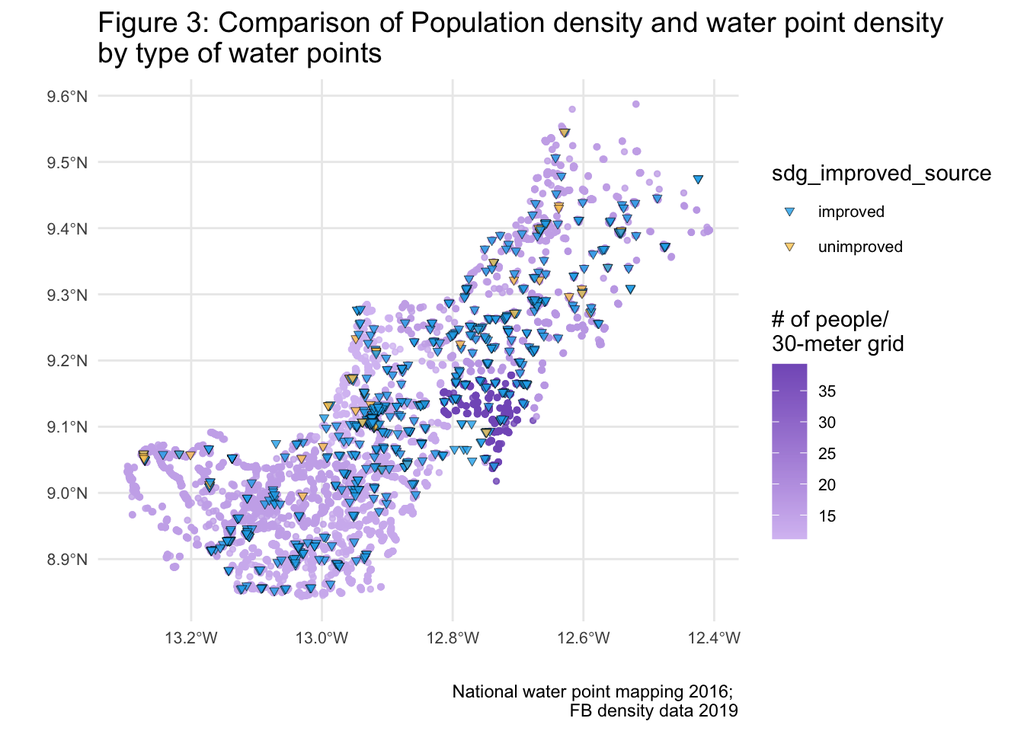

Figure 4 shows the location of the different water points in Kambia along with their functionality status. The highest concentration of water points are seen to be in the middle and more to the southern part of the district and the lowest concentration is in the outer fringes. Along the eastern border there seem to be quite some non functional water points.

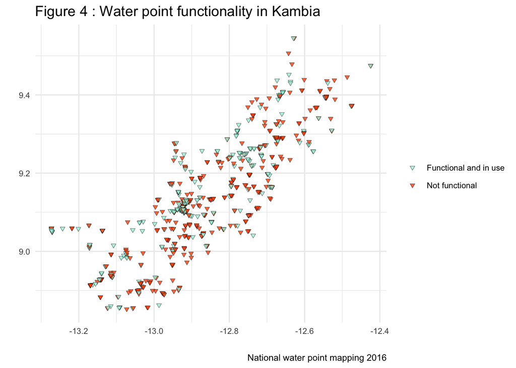

When the improved water points are further classified by functionality, the ‘coverage’ dips and we see many of the listed ‘covered’ regions to be having water points that are non or partially functional, and therefore not catering to their intended coverage. These visuals help planners and service providers to identify the focus areas for repair and maintenance and in reality should not be included as covered areas.

As shown in Figure 3, in Figure 5 when we overlay the population densities over the density of water points in Kambia using the functionality parameters, the size of the uncovered population becomes larger. Clearly, there are sizable sections of the communities in Kambia who do not have access to even basic water supply services and even larger numbers who may be considered ‘covered’ but in reality receive none or sub normal services and probably depend on walking long distances to collect water from the closest functioning water source or resort to unimproved and unsafe water sources.

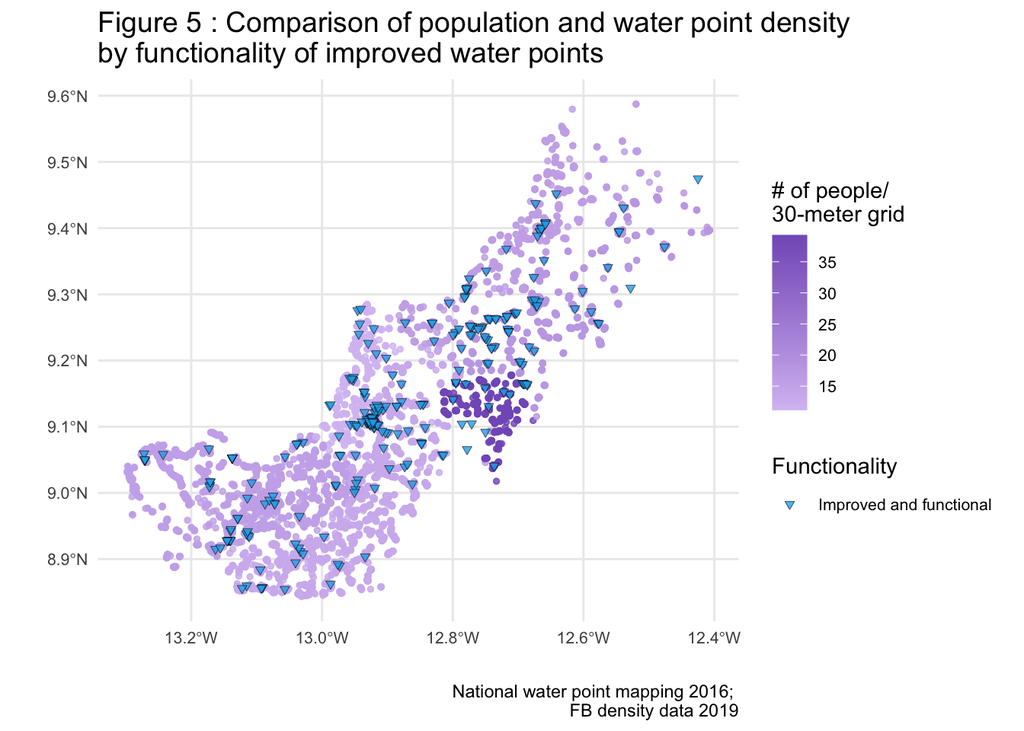

## 2.2 Using Population projections to estimate projected need for water services

If we want to see how many people live close enough to the water points for the water supply to be considered “basic” water service level, we need to combine the population density data with the water point locations. By taking an area around the water point and determining how many people live within that area, we can first determine the population that is close enough to the water point. Next, we will compare the amount of people to the amount of people the water point can serve based on the sphere guidelines. By looking at the intersection and comparing that to the total population we can determine the percentage of the population actually served. Below we will follow these steps one by one.

1. Draw a circle around the water points that represents the 30 min round trip. We will use a 500m radius, which represents a 1 kilometer walk back and forth. This allows for additional time that comes from following a road and some time for queuing.
2. Account for overlapping circles.
3. Determine the population living withing the 500m radius of a water point.
4. Compare the population living within the radius to the capacity of the water point.
5. Include the population living outside of the radius to determine the percentage of the population likely to be served by the water point.

Table 7 (a): Population covered by ‘improved’ water points

| District | variable | value |
| --- | --- | --- |
| Kambia | Total population | 366827.8 |
| Kambia | Projected percentage of the population served by the water point (in the 500m radius) | 64.0 |
| Kambia | Projected percentage of the population depending the water supply | 38.0 |

<sup>a</sup> National water point mapping 2016  
<sup>b</sup> FB density 2019

```r
# summarise the population density per water point
# population_dens_per_wp <- improved_kept_points_with_ID_no_geometry %>%
#   group_by(Water.point.Name, ADM2, sphere_nr_people) %>%
#   summarise(Population_within_circle = sum(Population, na.rm=TRUE))
#
# population_dens_per_wp <- population_dens_per_wp %>%
#   mutate(sphere_nr_people = replace_na(sphere_nr_people, 0)) %>%
#   mutate(Percentage_served_within_circle = round(sphere_nr_people/Population_within_circle,2)*100) %>%
#   mutate(percentage_actually_served = ifelse(Percentage_served_within_circle > 100, 100, Percentage_served_within_circle))
#
# pop_served <- wp_2016_int_circles %>%
#   st_transform(4269) %>%
#   left_join(population_dens_per_wp)
#
# ggplot() +
#   geom_sf(data = pop_served, aes(color=percentage_actually_served), alpha=0.8, size = 1) +
#   theme_minimal() +
#   scale_color_gradient(low="#d43d51", high="#6aaa96", breaks=c(25, 50, 75, 100)) +
#   labs(title="Figure 5: Proportion of the population projected to served", color="")
```

## 2.3 Example 2: Making projections for access to ‘Improved’ and functional water points

Tables 7(a) and 7(b) provide details of how the coverage data changes when we consider only the improved and functional water points that are not damaged and in use at time of the data collection:

Table 7 (b) : Population covered by functional and improved water points

| District | variable | value |
| --- | --- | --- |
| Kambia | Total population | 366827.8 |
| Kambia | Projected percentage of the population served by the water point (in the 500m radius) | 48.0 |
| Kambia | Projected percentage of the population depending the water supply | 19.0 |

<sup>a</sup> National water point mapping 2016  
<sup>b</sup> FB density 2019

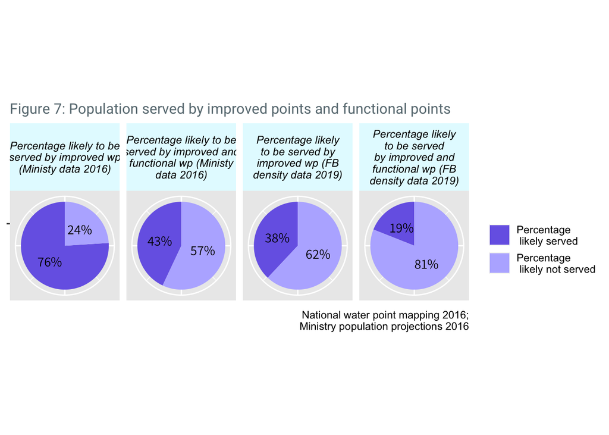

# 3 Annex 1: data sources

## 3.1 National Water Point mapping 2016[^3]

The Sierra Leone WASH portal is a comprehensive mapping exercise carried out by the Ministry of Water Resources (MOWR) and its partners in 2016. Over 28,000 public improved water points across all of Sierra Leone’s districts and chiefdoms have been mapped during this period. The exercise constitutes a comprehensive update of the earlier mapping in 2012.

## 3.2 Sphere guidelines

The Sphere movement was started in 1997 by a group of humanitarian professionals aiming to improve the quality of humanitarian work during disaster response. With this goal in mind, they framed a Humanitarian Charter and identified a set of humanitarian standards to be applied in humanitarian response. During a disaster the standards for water supply are generally lower than for normal domestic use. Because of the nature of humanitarian response using the Sphere guidelines might cause the numbers to be more favorable than they actually are.

## 3.3 Sierra Leone 2015 Population and Housing CensusThematic Report on Population Projections

## 3.4 High Resolution Population Density Maps

Accurate population density data is critical for delivery of social services. Facebook has built the world’s most accurate population maps using satellite imagery.

[^1]: https://spherestandards.org/wp-content/uploads/Sphere-Handbook-2018-EN.pdf
[^2]: https://www.statistics.sl/images/StatisticsSL/Documents/Census/2015/sl_2015_phc_thematic_report_on_population_projections.pdf
[^3]: https://washdata-sl.org/water-point-data/